# Projet Modèle Spartiale

Pâquarse Delvich Van Mahouvi

2022-09-29

# clear data & close graphs

```r
rm(list=ls())
graphics.off()
```

# Définition du répertoire

```r
setwd("~/Cours M2 MAS/Modele de donnees spartiales/Projet Delvich-Ronan-Romain")
```

# Les packages

```r
library(magrittr)
library(RColorBrewer)
library(hrbrthemes)
library(rgdal)
library(dplyr)
```

# 1 Ouverture de la base

```r
base <- openxlsx::read.xlsx(xlsxFile = "bdd_projet.xlsx", rowNames = TRUE)
```

# 2 Pré-traitement des données

## 2.1 Vue partielle des données

```r
stargazer::stargazer(base, type = "text")
```

```
===============================================================
Statistic                     N   Mean   St. Dev.  Min    Max
---------------------------------------------------------------
Cambriolage                   96  5.835   2.302   1.900  12.100
Taux_chomage_2019             96  8.125   1.588   4.925  13.625
Domicile_au_moins_une_voiture 96 84.842   7.183   33.500 91.800
T_Crea_Entr                   96 14.736   2.843   9.100  24.200
Pop_active                    96 44.936   2.297   39.893 55.033
Ratio_homme_femme             96  0.942   0.019   0.880  0.990
Part_Maison                   96 63.217   17.420  0.800  86.500
Part_Appartement              96 35.861   17.255  12.900 96.900
Taux_Pauvrete                 96 14.367   2.985   9.100  27.900
Policier_Gendarme             96  3.223   1.262   1.600  11.700
Personne_Seule                96 369.000  31.708   294    518
---------------------------------------------------------------
```

```r
str(base)
```

```
'data.frame':   96 obs. of  12 variables:
 $ Code                         : chr  "01" "02" "03" "04" ...
 $ Cambriolage                  : num  8.2 7 5 5 2.4 8 4.6 4.6 4.4 6.8 ...
 $ Taux_chomage_2019            : num  6.05 11.65 8.9 9.75 7.97 ...
 $ Domicile_au_moins_une_voiture: num  91 83.1 85 87.9 88.4 77.7 90 83 87.7 82.7 ...
 $ T_Crea_Entr                  : num  16.5 13.7 11.5 13 11.7 14.9 13.7 12.4 13.6 13.9 ...
 $ Pop_active                   : num  47.9 44.5 42.6 42.7 45.2 ...
 $ Ratio_homme_femme            : num  0.97 0.95 0.92 0.96 0.96 0.9 0.95 0.95 0.97 0.94 ...
 $ Part_Maison                  : num  63.2 75.5 71.7 60.8 43.1 23.7 74.7 71.1 79.6 65.6 ...
 $ Part_Appartement             : num  36 23.7 27.6 38 56.2 75.6 24.5 28.2 19.1 33.4 ...
 $ Taux_Pauvrete                : num  10.7 18.4 15.4 16.6 13.9 15.8 14.3 18.6 17.9 16.3 ...
 $ Policier_Gendarme            : num  2 3 4.1 3.9 4.5 3.3 2.6 3.5 3.7 3.2 ...
 $ Personne_Seule               : num  322 338 413 389 389 402 356 352 388 386 ...
```

```r
head(base)
```

```
                        Code Cambriolage Taux_chomage_2019
AIN                       01         8.2             6.050
AISNE                     02         7.0            11.650
ALLIER                    03         5.0             8.900
ALPES-DE-HAUTE-PROVENCE   04         5.0             9.750
HAUTES-ALPES              05         2.4             7.975
ALPES-MARITIMES           06         8.0             8.775
                        Domicile_au_moins_une_voiture T_Crea_Entr Pop_active
AIN                                              91.0        16.5   47.85126
AISNE                                            83.1        13.7   44.51348
ALLIER                                           85.0        11.5   42.57182
ALPES-DE-HAUTE-PROVENCE                          87.9        13.0   42.67372
HAUTES-ALPES                                     88.4        11.7   45.18960
ALPES-MARITIMES                                  77.7        14.9   44.38945
                        Ratio_homme_femme Part_Maison Part_Appartement
AIN                                  0.97        63.2             36.0
AISNE                                0.95        75.5             23.7
ALLIER                               0.92        71.7             27.6
ALPES-DE-HAUTE-PROVENCE              0.96        60.8             38.0
HAUTES-ALPES                         0.96        43.1             56.2
ALPES-MARITIMES                      0.90        23.7             75.6
                        Taux_Pauvrete Policier_Gendarme Personne_Seule
AIN                              10.7               2.0            322
AISNE                            18.4               3.0            338
ALLIER                           15.4               4.1            413
ALPES-DE-HAUTE-PROVENCE          16.6               3.9            389
HAUTES-ALPES                     13.9               4.5            389
ALPES-MARITIMES                  15.8               3.3            402
```

```r
# La présence de valeurs manquantes
sum(is.na(base))
```

```
[1] 0
```

On peut donc remarquer l’absence de valeurs manquantes dans notre base de données.

# Statistique descriptive Univarié

## BoxPlot du taux de cambriolage pour 1000 habitants

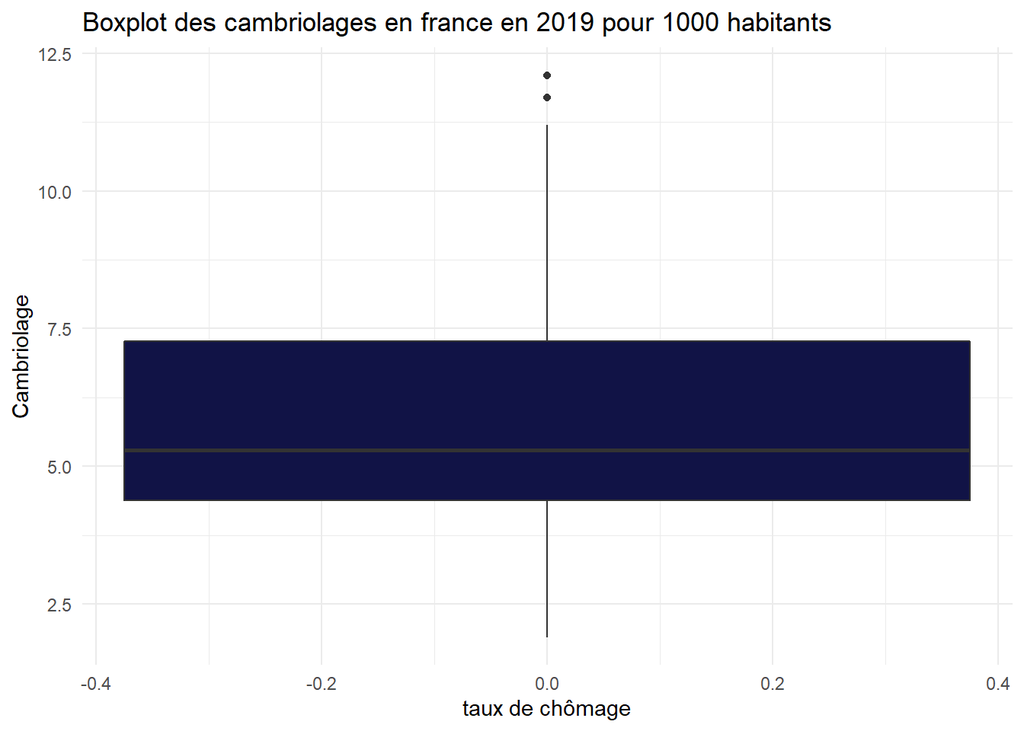

```r
library(ggplot2)
ggplot(base) +
  aes(x = Cambriolage) +
  geom_boxplot(fill = "#111346", position = "dodge2", orientation = "y") +
  labs(y = "taux de chômage",title = "Boxplot des cambriolages en france en 2019 pour 1000 habitants") +
  theme_minimal() +
  theme(plot.subtitle = element_text(face = "italic")) +
  coord_flip()
```

## Cartographie du taux de cambriolage pour 1000 habitants

```r
# lecture du shapefile
carte <- raster::getData('GADM', country='FRA', level=2)
# fusion des tables et suppression des variables inutiles
carte@data <- merge(carte@data, base, by.x = "CC_2", by.y = "Code")

# fusion des tables et suppression des variables inutiles
carte@data <- carte@data%>%
  dplyr::select(c("CC_2", "Cambriolage","NAME_1", "NAME_2", "Domicile_au_moins_une_voiture", "Pop_active", "Ratio_homme_femme", "Taux_chomage_2019","T_Crea_Entr", "Ratio_homme_femme", "Part_Maison", "Part_Appartement", "Taux_Pauvrete", "Policier_Gendarme", "Personne_Seule"
                  ))
```

La carte

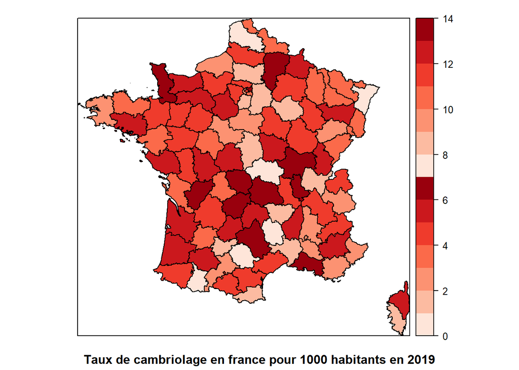

```r
sp::spplot(carte, "Cambriolage", sub = "Taux de cambriolage en france pour 1000 habitants en 2019",
           at = seq(0, 14, 1), col.regions = brewer.pal(7, "Reds"),
           border = "white")
```

## Statistiques bivariée

### Matrice de corrélation des variables explicatives

```r
cor.mtest <- function(mat, ...) {
  mat <- as.matrix(mat)
  n <- ncol(mat)
  p.mat<- matrix(NA, n, n)
  diag(p.mat) <- 0
  for (i in 1:(n - 1)) {
    for (j in (i + 1):n) {
      tmp <- cor.test(mat[, i], mat[, j], ...)
      p.mat[i, j] <- p.mat[j, i] <- tmp$p.value
    }
  }
  colnames(p.mat) <- rownames(p.mat) <- colnames(mat)
  p.mat
}

# Matrice de p-value de la corrélation
p.mat <- cor.mtest(base[,-1])

# Affichage pour sortir
stargazer::stargazer(p.mat, type = "text", title = "Matrice de corrélation")
```

```
Matrice de corrélation
==============================================================================================================================================================================================================
                              Cambriolage Taux_chomage_2019 Domicile_au_moins_une_voiture T_Crea_Entr Pop_active Ratio_homme_femme Part_Maison Part_Appartement Taux_Pauvrete Policier_Gendarme Personne_Seule
--------------------------------------------------------------------------------------------------------------------------------------------------------------------------------------------------------------
Cambriolage                        0            0.001                  0.00003                 0        0.001          0.041         0.00000       0.00000          0.003           0.713           0.130
Taux_chomage_2019                0.001            0                     0.416                0.144     0.00004         0.007          0.934         0.943             0             0.897           0.470
Domicile_au_moins_une_voiture   0.00003         0.416                     0                 0.00000       0           0.00002           0             0             0.003             0            0.00004
T_Crea_Entr                        0            0.144                  0.00000                 0       0.00000         0.034            0             0             0.190           0.802           0.028
Pop_active                       0.001         0.00004                    0                 0.00000       0            0.310            0             0             0.001           0.007           0.663
Ratio_homme_femme                0.041          0.007                  0.00002               0.034      0.310            0            0.005         0.005           0.084           0.004          0.00000
Part_Maison                     0.00000         0.934                     0                    0          0            0.005            0             0             0.272          0.0001           0.086
Part_Appartement                0.00000         0.943                     0                    0          0            0.005            0             0             0.280          0.0001           0.085
Taux_Pauvrete                    0.003            0                     0.003                0.190      0.001          0.084          0.272         0.280             0             0.013           0.990
Policier_Gendarme                0.713          0.897                     0                  0.802      0.007          0.004         0.0001         0.0001          0.013             0            0.00001
Personne_Seule                   0.130          0.470                  0.00004               0.028      0.663         0.00000         0.086         0.085           0.990          0.00001            0
--------------------------------------------------------------------------------------------------------------------------------------------------------------------------------------------------------------
```

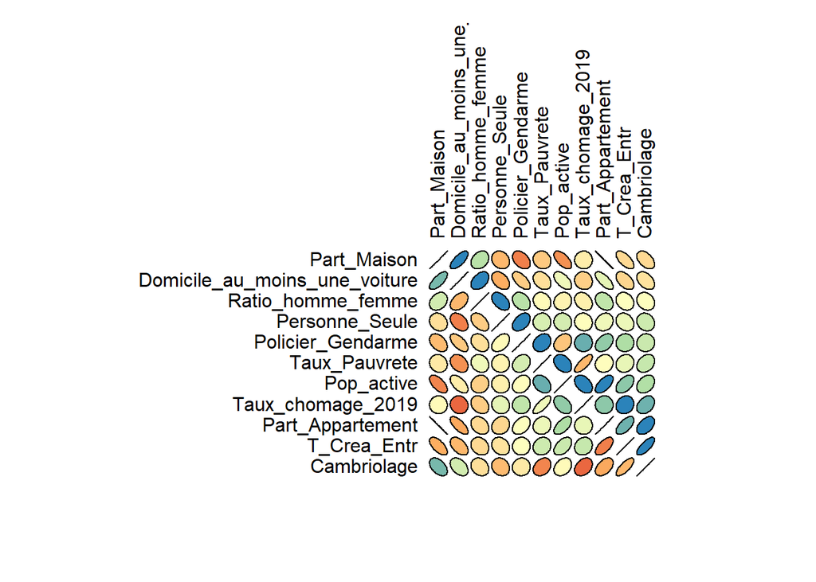

```r
M <- cor(base[,-1])
my_colors <- brewer.pal(5, "Spectral")
my_colors <- colorRampPalette(my_colors)(100)
ord <- order(M[1, ])
M_ord <- M[ord, ord]
ellipse::plotcorr(M_ord , col=my_colors[M_ord*50+50] , mar=c(1,1,1,1))
```

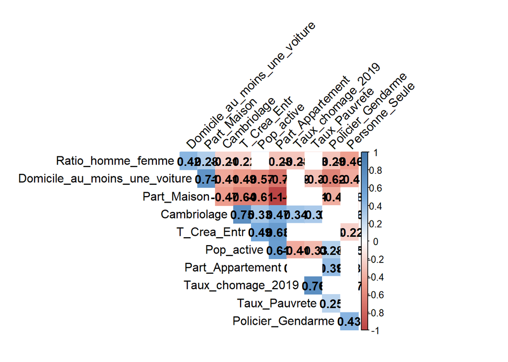

```r
col <- colorRampPalette(c("#BB4444", "#EE9988", "#FFFFFF", "#77AADD", "#4477AA"))
corrplot::corrplot(M, method="color", col=col(200),
         type="upper", order="hclust",
         addCoef.col = "black", # Ajout du coefficient de corrélation
         tl.col="black", tl.srt=45, #Rotation des etiquettes de textes
         # Combiner avec le niveau de significativité
         p.mat = p.mat, sig.level = 0.05, insig = "blank",
         # Cacher les coefficients de corrélation sur la diagonale
         diag=FALSE
)
```

```r
rm(my_colors, ord, p.mat, col, cor.mtest, M_ord)
```

### Choix des variables explicatives pour la suite

```r
carte@data <- carte@data%>%
  dplyr::select(c("CC_2", "Cambriolage","NAME_1", "NAME_2", "Taux_chomage_2019", "Part_Maison", "Policier_Gendarme", "Personne_Seule"))

base <- base%>%
  dplyr::select(c("Code", "Cambriolage", "Taux_chomage_2019","Part_Maison", "Policier_Gendarme", "Personne_Seule"))
```

# Analyse

## Définition de la matrice des poids : Relations basées sur la connectivité :

```r
coord <-coordinates(carte)
```

### Définition de la matrice des poids - Connectivité : Alternative Contiguity matrix

```r
library(spdep)
carte.nb <- poly2nb(carte)
```

```r
summary(carte.nb)
```

```
Neighbour list object:
Number of regions: 96
Number of nonzero links: 478
Percentage nonzero weights: 5.186632
Average number of links: 4.979167
Link number distribution:

 1  2  3  4  5  6  7  8 10
 2  6 10 16 19 30 11  1  1
2 least connected regions:
67 68 with 1 link
1 most connected region:
87 with 10 links
```

On remarque que les centroides ont en moyenne 4.979167 liens. Affichage des liens

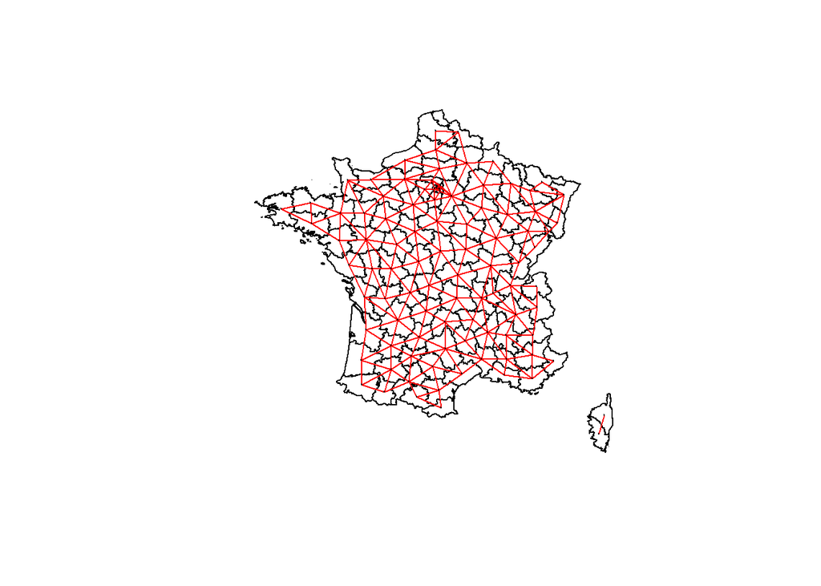

```r
# Affichage des liens
plot(carte)
plot(carte.nb, col="red",cex=0.1,coord,add=TRUE)
```

```r
cont.w <- nb2listw(carte.nb,style="W")
cont.w
```

```
Characteristics of weights list object:
Neighbour list object:
Number of regions: 96
Number of nonzero links: 478
Percentage nonzero weights: 5.186632
Average number of links: 4.979167

Weights style: W
Weights constants summary:
   n   nn S0       S1      S2
W 96 9216 96 44.07222 391.414
```

La fonction nb2listw complète la liste de voisins avec des poids spatiaux pour le schéma de codage choisi. La fonction d’aide can.be.simmed vérifie si un objet de poids spatial est similaire à symétrique et peut être transformé de cette façon pour produire des valeurs propres réelles ou pour la décomposition de Cholesky.

–> On regarde que les villes ont en moyenne 5 voisins en moyennes

### Définition de la matrice des poids - Connectivité : Alternative Closest neighbors

```r
### Definition of the 5 closest neighbors
cartePPV5.knn<-knearneigh(coord,k=5)
cartePPV5.nb<- knn2nb(cartePPV5.knn)
# Matrice de poids
PPV5.w<-nb2listw(cartePPV5.nb,style="W")
```

### Définition de la matrice des poids - Euclidean distance

Relation basée sur l’inverse de la distance. Prendre l’inverse de la distance est la manière la plus naturelle de modéliser une influence décroissante avec la distance.

Ici, nous travaillons avec des département (96), donc les distances entre département sont plus faibles que les distances entre commune (vu en cours). Malgré ces petites valeurs, il faudra également divisée par 1000 pour avoir les distances en km et ainsi opéré un choix pour lambda en nous basant sur le graphique de la page 47 du chapitre 1.

```r
distance<- fields::rdist(coord,coord)/1000 #for a distance in km
# La règle des distances notifie que la diagonale doit être égale à 0
diag(distance)<-0
```

–> Choix du seuil et Choix de lambda

Pour le choix du seuil de dichotomisation, on a choisit d’évaluer sur la matrice des distances, la distance moyenne qui sépare les département entre eux. Pour avoir une répartition pas trop déséquilibrée, on a donc pris la médiance des moyennes. Par exempe, pour le département d’Ile et Vilaine, on a pris la distance moyenne entre ledit département et tous les autres. Ceci répété pour tous les départements, ensuite on a pris la médiane des moyennes.

Par ailleurs, pour le choix de lambda, on a opté pour lambda = 1, ainsi, on accorde plus de poids aux variables qui sont spatialement plus proches (plus petite distance) afin de laisser moins de poids aux variables plus éloignées.

```r
# Choix du seuil
seuil <- median(apply(distance, MARGIN = 2, FUN = mean))

# Dichotomisation
distance[distance>= seuil ]<-0

#gamma =1
dist1<- ifelse(distance>0, 1.0/distance,0)

# Matrice de poids
dist.w1<-mat2listw(dist1, row.names = NULL, style="W")
rm(seuil, distance, dist1)
```

Ainsi, nous avons les 3 matrices de poids :

- Matrice de contiguite (connectivity) : cont.w
- Critère des plus proche voisins (connectivity) : PPV5.w
- Inverse de la distance (lambda = 1) : dist.w1

## Comparaison des statistiques

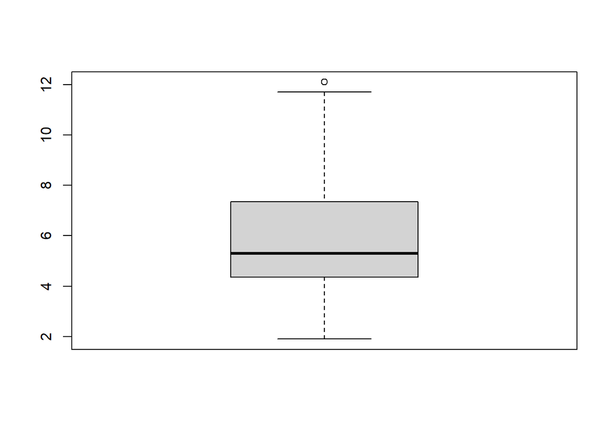

```r
cambriolage <- cbind(base$Cambriolage)
cont.w_cambriolage <- lag.listw(cont.w, cambriolage)
ppv5.w_cambriolage <- lag.listw(PPV5.w, cambriolage)
dist.w1_cambriolage <- lag.listw(dist.w1, cambriolage)
graphics::boxplot.matrix(cambriolage)
```

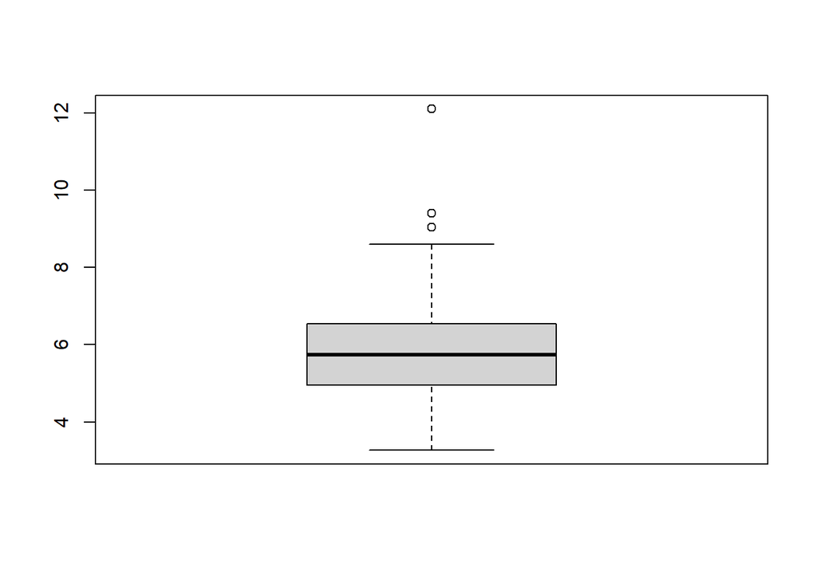

```r
graphics::boxplot.matrix(cont.w_cambriolage)
```

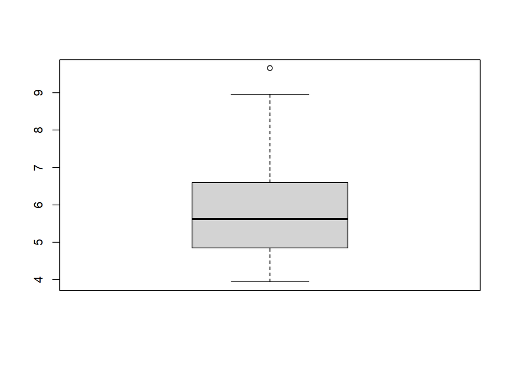

```r
graphics::boxplot.matrix(ppv5.w_cambriolage)
```

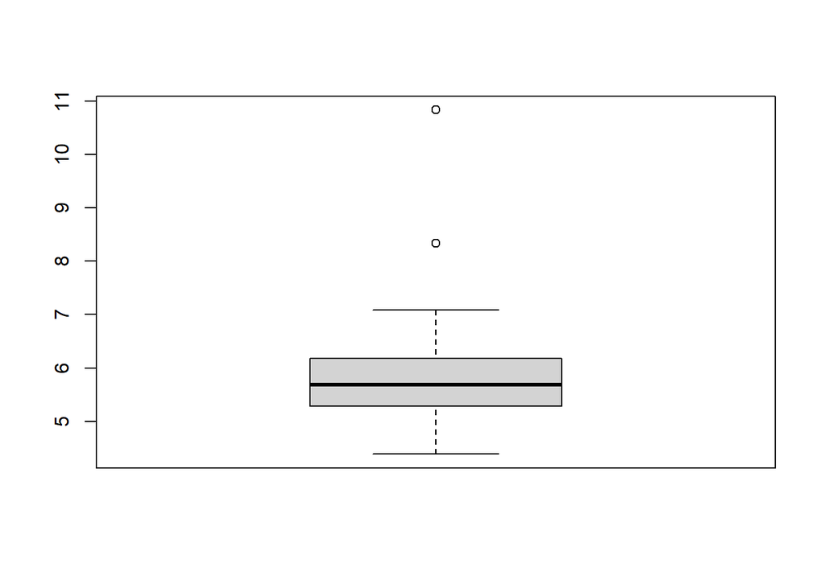

```r
graphics::boxplot.matrix(dist.w1_cambriolage)
```

```r
rm(cambriolage, cont.w_cambriolage, ppv5.w_cambriolage, dist.w1_cambriolage)
```

## Analyse de l’autocorrélation Spartiale Globale : Indice de Moran

Les indices d’autocorrélation spatiale sont utilisés pour caractériser la corrélation entre les mesures qui sont géographiquement similaires à un phénomène mesuré. Si WY est le vecteur des moyennes de la variable Y (où W est la matrice des poids spatiaux) au voisinage de chaque unité spatiale, les indices d’autocorrélation spatiale se présentent comme suit : (confère cours p.9 chapter 2).

- H0 : no spatial autocorrelation

Pour eviter les problèmes liés à la dimension, nous allons centrés la variable cible

```r
carte$Cambriolage_centered <- carte$Cambriolage - mean(carte$Cambriolage)
```

### Matrice de contiguite

#### Autocorrelation Spatiale Globale

```r
MoranTest_Cont_W <- moran.test(carte$Cambriolage_centered, cont.w, randomisation = FALSE,
                               alternative = "greater")

MoranTest_Cont_W
```

```
    Moran I test under normality

data:  carte$Cambriolage_centered
weights: cont.w

Moran I statistic standard deviate = 1.5276, p-value = 0.06331
alternative hypothesis: greater
sample estimates:
Moran I statistic       Expectation          Variance
      0.092570053      -0.010526316       0.004554958
```

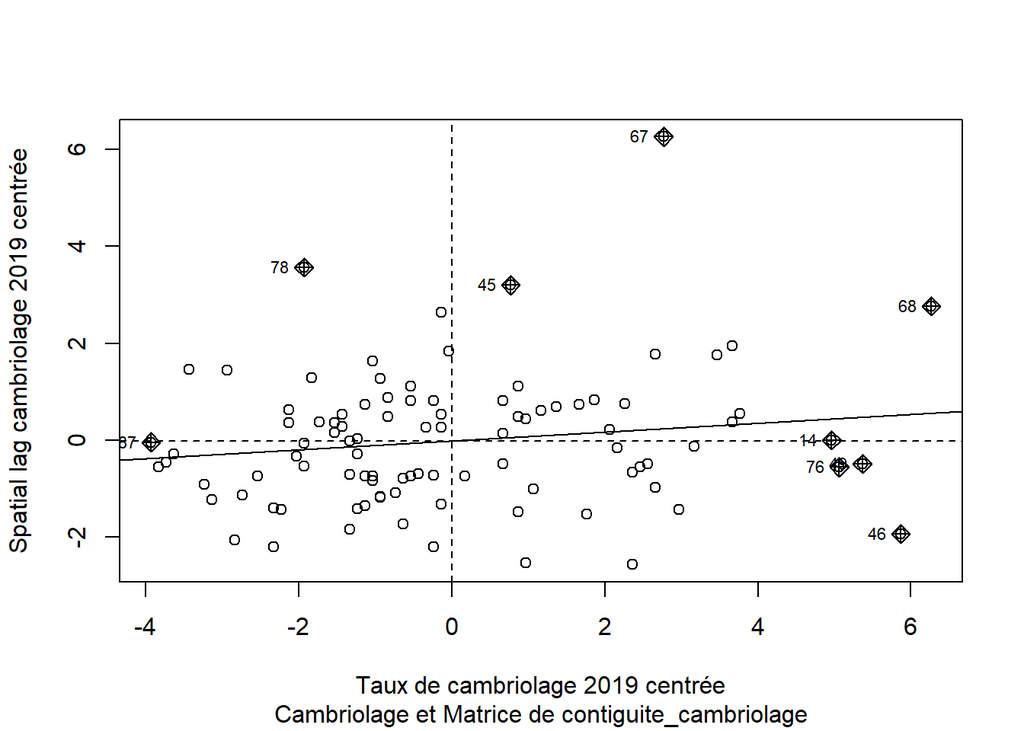

```r
moran.plot(x = carte$Cambriolage_centered, listw = cont.w, xlab = "Taux de cambriolage 2019 centrée", ylab = "Spatial lag cambriolage 2019 centrée", sub = "Cambriolage et Matrice de contiguite_cambriolage",
           labels = as.character(row.names(carte)))
```

- Interprétation :

Moran I statistic standard deviate = 1.5276 > 0 ==> Possible Positive spartial autocorrelation p-value = 0.06331 > 0.05 ==> On ne rejette pas HO (No Spatial Correlation)

#### Autocorrelaytion Spatiale locale (LISA)

```r
locm_w <-localmoran(carte$Cambriolage_centered, cont.w)
head(locm_w)
```

[output not shown]

```r
summary(locm_w)
```

```
       Ii                E.Ii                Var.Ii              Z.Ii
 Min.   :-2.16413   Min.   :-7.876e-02   Min.   :0.000038   Min.   :-2.7974
 1st Qu.:-0.12911   1st Qu.:-1.346e-02   1st Qu.:0.025591   1st Qu.:-0.5891
 Median : 0.03409   Median :-4.433e-03   Median :0.094415   Median : 0.1971
 Mean   : 0.09257   Mean   :-1.053e-02   Mean   :0.281479   Mean   : 0.1448
 3rd Qu.: 0.21659   3rd Qu.:-1.500e-03   3rd Qu.:0.295164   3rd Qu.: 0.8613
 Max.   : 3.30213   Max.   :-2.520e-06   Max.   :6.965858   Max.   : 2.7550
 Pr(z != E(Ii))
 Min.   :0.005152
 1st Qu.:0.199421
 Median :0.415789
 Mean   :0.430990
 3rd Qu.:0.609910
 Max.   :0.978165
```

#### Cartes des LISAs prenant en compte la significativité

```r
carte$ContW_cambriolage <- lag.listw(cont.w, carte$Cambriolage_centered)
#create a new variable for quadrants
carte$quad_sig <- NA

#HH
carte@data[(carte$Cambriolage_centered >= 0 & carte$ContW_cambriolage >= 0) & (locm_w[,5] <= 0.05), "quad_sig"] <- 1.0

#LL
carte@data[(carte$Cambriolage_centered <= 0 & carte$ContW_cambriolage <= 0) & (locm_w[,5] <= 0.05), "quad_sig"] <- 2.0

#HL
carte@data[(carte$Cambriolage_centered >= 0 & carte$ContW_cambriolage <= 0) & (locm_w[,5] <= 0.05), "quad_sig"] <- 3.0

#LH
carte@data[(carte$Cambriolage_centered <= 0 & carte$ContW_cambriolage >= 0) & (locm_w[,5] <= 0.05), "quad_sig"] <- 4.0

#pas significatifs
carte@data[(locm_w[,5] > 0.05), "quad_sig"] <- 5.0

table(carte$quad_sig)
```

```
 1  3  4  5
 3  2  3 88
```

```r
labels <- c("high-High", "low-Low", "High-Low", "Low-High", "Not Signif.")

# need for the map
help("findInterval")
```

```
démarrage du serveur d'aide httpd ... fini
```

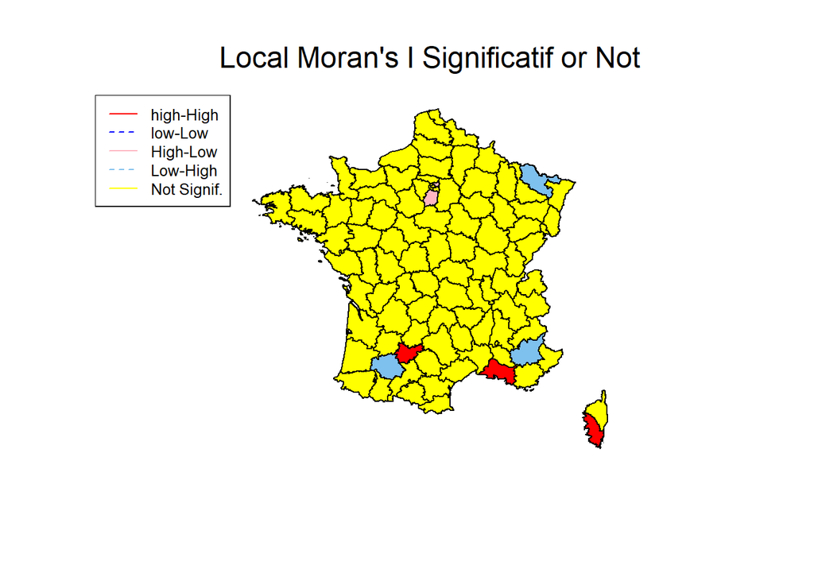

```r
breaks <- seq(1, 5, 1)

carte$np <- findInterval(carte$quad_sig, breaks)

col.map <- c("red",  "blue","lightpink", "skyblue2", "yellow")
plot(carte, col = col.map[carte$np])
mtext("Local Moran's I Significatif or Not", cex = 1.5, side = 3, line = 1)
legend("topleft", legend = labels, col=c("red",  "blue","lightpink", "skyblue2","yellow"), lty=1:2, cex=0.8)
```

### Matrice des plus proches voisins

#### Indice de Moral

```r
MoranTest_ppv5.w <- moran.test(carte$Cambriolage_centered, PPV5.w, randomisation = FALSE,
                               alternative = "greater")

MoranTest_ppv5.w
```

```
    Moran I test under normality

data:  carte$Cambriolage_centered
weights: PPV5.w

Moran I statistic standard deviate = 2.2755, p-value = 0.01144
alternative hypothesis: greater
sample estimates:
Moran I statistic       Expectation          Variance
       0.12326334       -0.01052632        0.00345693
```

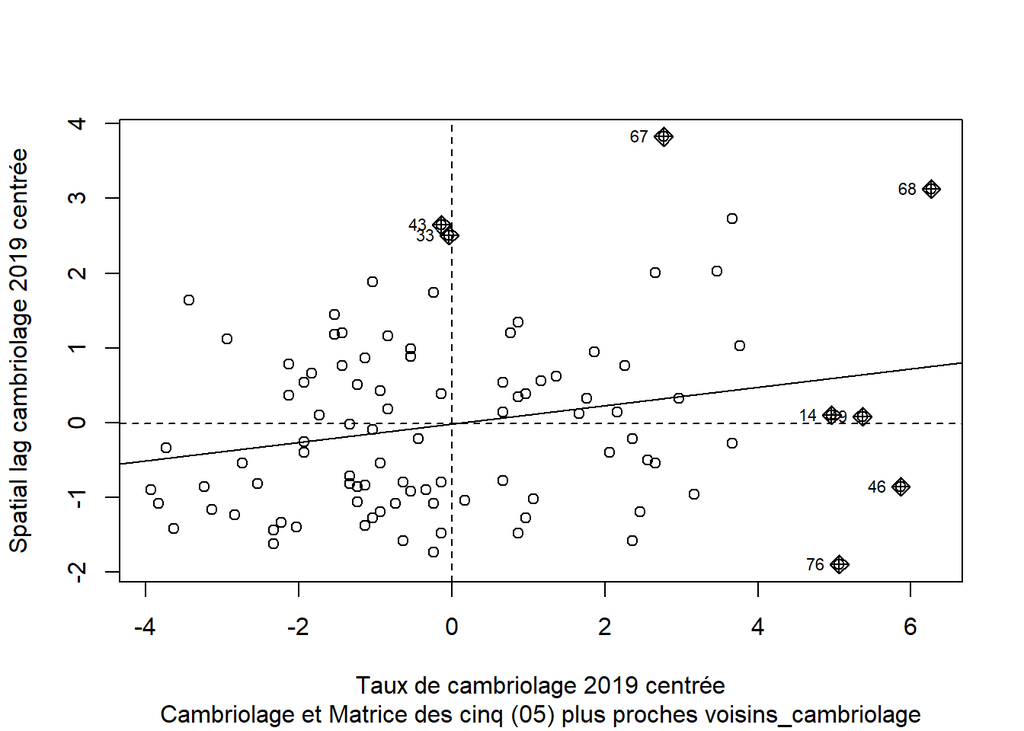

```r
moran.plot(x = carte$Cambriolage_centered, listw = PPV5.w, xlab = "Taux de cambriolage 2019 centrée", ylab = "Spatial lag cambriolage 2019 centrée", sub = "Cambriolage et Matrice des cinq (05) plus proches voisins_cambriolage",
           labels = as.character(row.names(carte)))
```

- Interprétation :

Moran I statistic standard deviate = 2.2755 > 0 ==> Positive spartial autocorrelation p-value = 0.01144 < 0.05 ==> On rejette HO (Spatial Autocorrelation)

#### Autocorrelaytion Spatiale locale (LISA)

```r
locm_ppv <-localmoran(carte$Cambriolage_centered, PPV5.w)
head(locm_ppv)
```

```
           Ii         E.Ii     Var.Ii       Z.Ii Pr(z != E(Ii))
1 -0.09711941 -0.011221677 0.20397295 -0.1901934      0.8491576
2  0.12536339 -0.002722010 0.04990244  0.5733750      0.5663908
3 -0.02940138 -0.001400731 0.02571354 -0.1746173      0.8613804
4 -0.18550082 -0.001400731 0.02571354 -1.1480823      0.2509346
5 -1.07722747 -0.023686852 0.42512082 -1.6158279      0.1061315
6  0.05967118 -0.009403665 0.17124178  0.1669226      0.8674310
```

```r
summary(locm_ppv)
```

```
       Ii                E.Ii                Var.Ii               Z.Ii
 Min.   :-1.83029   Min.   :-7.876e-02   Min.   :0.0000463   Min.   :-2.6237
 1st Qu.:-0.15024   1st Qu.:-1.346e-02   1st Qu.:0.0275376   1st Qu.:-0.7491
 Median : 0.05847   Median :-4.433e-03   Median :0.0811361   Median : 0.3465
 Mean   : 0.12326   Mean   :-1.053e-02   Mean   :0.1875115   Mean   : 0.2163
 3rd Qu.: 0.22596   3rd Qu.:-1.500e-03   3rd Qu.:0.2441476   3rd Qu.: 1.0641
 Max.   : 3.73213   Max.   :-2.520e-06   Max.   :1.3338876   Max.   : 3.8550
 Pr(z != E(Ii))
 Min.   :0.0001157
 1st Qu.:0.1955577
 Median :0.3721853
 Mean   :0.4111885
 3rd Qu.:0.6287198
 Max.   :0.9766180
```

#### Maps de Lisa

```r
carte$ppvW_cambriolage <- lag.listw(PPV5.w, carte$Cambriolage_centered)
#create a new variable for quadrants
base$quad_sig_ppv <- NA

#HH
carte@data[(carte$Cambriolage_centered >= 0 & carte$ppvW_cambriolage >= 0) & (locm_ppv[,5] <= 0.05), "quad_sig_ppv"] <- 1.0

#LL
carte@data[(carte$Cambriolage_centered <= 0 & carte$ppvW_cambriolage <= 0) & (locm_ppv[,5] <= 0.05), "quad_sig_ppv"] <- 2.0

#HL
carte@data[(carte$Cambriolage_centered >= 0 & carte$ppvW_cambriolage <= 0) & (locm_ppv[,5] <= 0.05), "quad_sig_ppv"] <- 3.0

#LH
carte@data[(carte$Cambriolage_centered <= 0 & carte$ppvW_cambriolage >= 0) & (locm_ppv[,5] <= 0.05), "quad_sig_ppv"] <- 4.0

#pas significatifs
carte@data[(locm_ppv[,5] > 0.05), "quad_sig_ppv"] <- 5.0

table(carte$quad_sig_ppv)
```

```
 1  4  5
 5  2 89
```

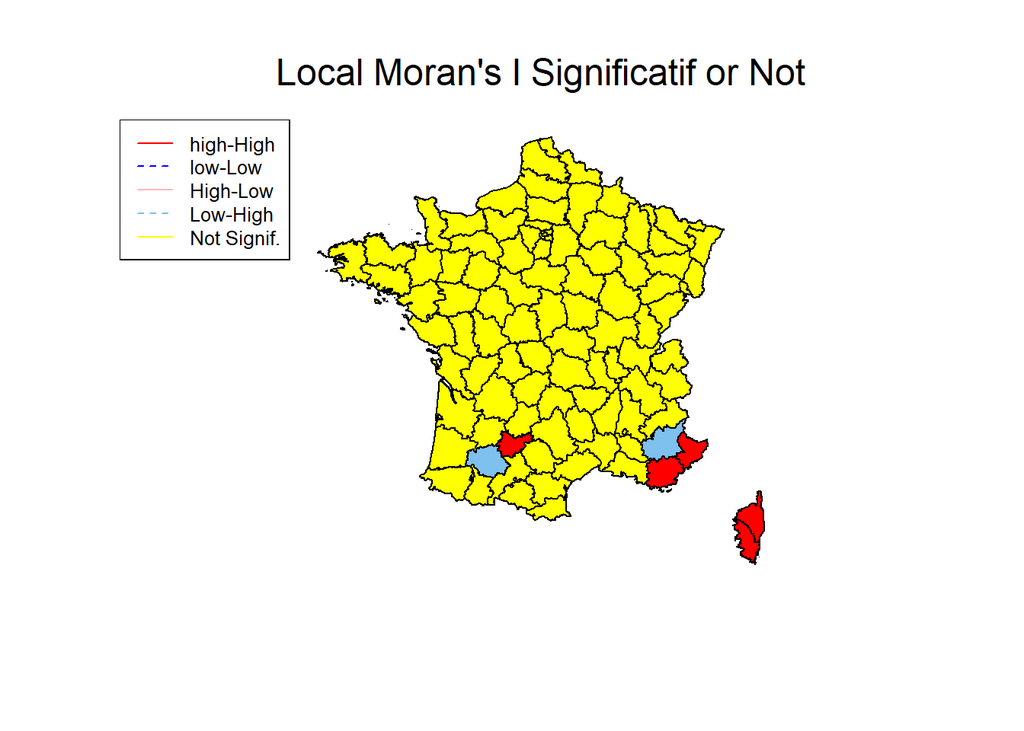

```r
labels <- c("high-High", "low-Low", "High-Low", "Low-High", "Not Signif.")

# need for the map
help("findInterval")
breaks <- seq(1, 5, 1)

carte$np_1 <- findInterval(carte$quad_sig_ppv, breaks)

col.map <- c("red",  "blue","lightpink", "skyblue2", "yellow")
plot(carte, col = col.map[carte$np_1])
mtext("Local Moran's I Significatif or Not", cex = 1.5, side = 3, line = 1)
legend("topleft", legend = labels, col=c("red",  "blue","lightpink", "skyblue2","yellow"), lty=1:2, cex=0.8)
```

### l’inverse de la distance

#### Indice de Moral

```r
MoranTest_dist.w1 <- moran.test(carte$Cambriolage_centered, dist.w1, randomisation = FALSE,
                               alternative = "greater")

MoranTest_dist.w1
```

```
    Moran I test under normality

data:  carte$Cambriolage_centered
weights: dist.w1

Moran I statistic standard deviate = 4.3791, p-value = 5.96e-06
alternative hypothesis: greater
sample estimates:
Moran I statistic       Expectation          Variance
     0.0987729599     -0.0105263158      0.0006229771
```

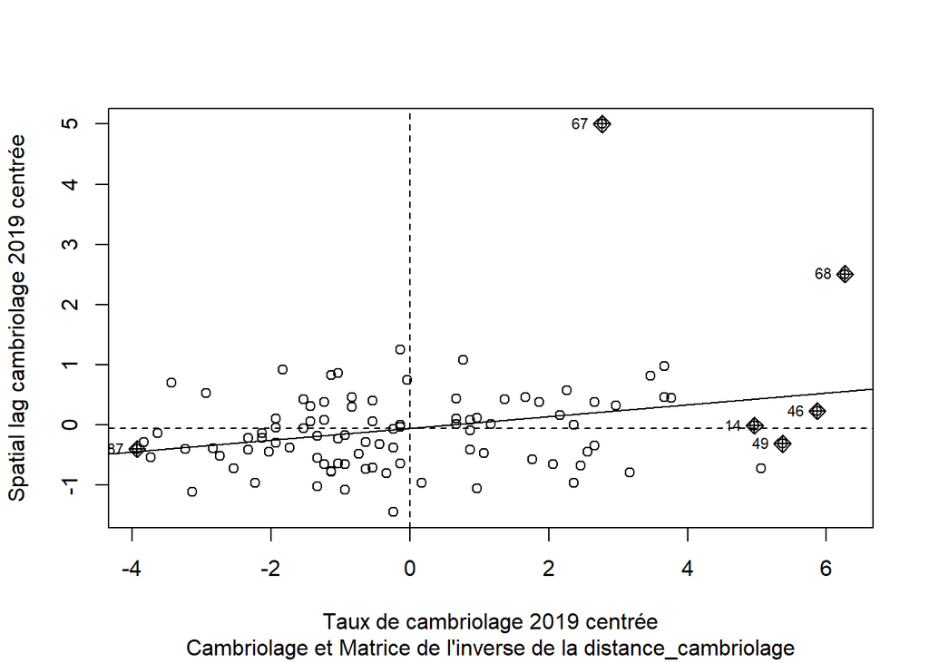

```r
moran.plot(x = carte$Cambriolage_centered, listw = dist.w1, xlab = "Taux de cambriolage 2019 centrée", ylab = "Spatial lag cambriolage 2019 centrée", sub = "Cambriolage et Matrice de l'inverse de la distance_cambriolage",labels = as.character(row.names(carte)))
```

- Interprétation :

Moran I statistic standard deviate = 4> 0 ==> Possible Positive spartial autocorrelation p-value = 6e-06 < 0.05 ==> On rejette HO (Spartial Autocorrelation)

#### Autocorrelation Spatial Local (LISA)

```r
locm_dist <-localmoran(carte$Cambriolage_centered, dist.w1)
head(locm_dist)
```

```
            Ii         E.Ii      Var.Ii        Z.Ii Pr(z != E(Ii))
1 -0.002251716 -0.011221677 0.015063191  0.07308564     0.94173797
2  0.001073872 -0.002722010 0.001712024  0.09173979     0.92690478
3 -0.073446969 -0.001400731 0.002213230 -1.53143325     0.12566235
4 -0.047639575 -0.001400731 0.001324925 -1.27031484     0.20397250
5 -0.455431872 -0.023686852 0.045847198 -2.01637329     0.04376096
6  0.067152881 -0.009403665 0.010304398  0.75417307     0.45074530
```

```r
summary(locm_dist)
```

```
       Ii                E.Ii                Var.Ii               Z.Ii
 Min.   :-0.70106   Min.   :-7.876e-02   Min.   :0.0000071   Min.   :-3.0021
 1st Qu.:-0.03402   1st Qu.:-1.346e-02   1st Qu.:0.0017767   1st Qu.:-1.1507
 Median : 0.03973   Median :-4.433e-03   Median :0.0076849   Median : 0.7165
 Mean   : 0.09877   Mean   :-1.053e-02   Mean   :0.0541316   Mean   : 0.4017
 3rd Qu.: 0.16853   3rd Qu.:-1.500e-03   3rd Qu.:0.0330086   3rd Qu.: 1.5842
 Max.   : 2.99508   Max.   :-2.520e-06   Max.   :2.2603645   Max.   : 3.5537
 Pr(z != E(Ii))
 Min.   :0.0003798
 1st Qu.:0.0550597
 Median :0.1690172
 Mean   :0.2828768
 3rd Qu.:0.4168653
 Max.   :0.9915076
```

#### Maps de Lisa

```r
carte$distw1_cambriolage <- lag.listw(dist.w1, carte$Cambriolage_centered)
#create a new variable for quadrants
carte$quad_sig_dist <- NA

#HH
carte@data[(carte$Cambriolage_centered >= 0 & carte$distw1_cambriolage >= 0) & (locm_dist[,5] <= 0.05), "quad_sig_dist"] <- 1.0

#LL
carte@data[(carte$Cambriolage_centered <= 0 & carte$distw1_cambriolage <= 0) & (locm_dist[,5] <= 0.05), "quad_sig_dist"] <- 2.0

#HL
carte@data[(carte$Cambriolage_centered >= 0 & carte$distw1_cambriolage <= 0) & (locm_dist[,5] <= 0.05), "quad_sig_dist"] <- 3.0

#LH
carte@data[(carte$Cambriolage_centered <= 0 & carte$distw1_cambriolage >= 0) & (locm_dist[,5] <= 0.05), "quad_sig_dist"] <- 4.0

#pas locm_dist
carte@data[(locm_dist[,5] > 0.05), "quad_sig_dist"] <- 5.0

table(carte$quad_sig_dist)
```

```
 1  2  3  4  5
 4 11  4  5 72
```

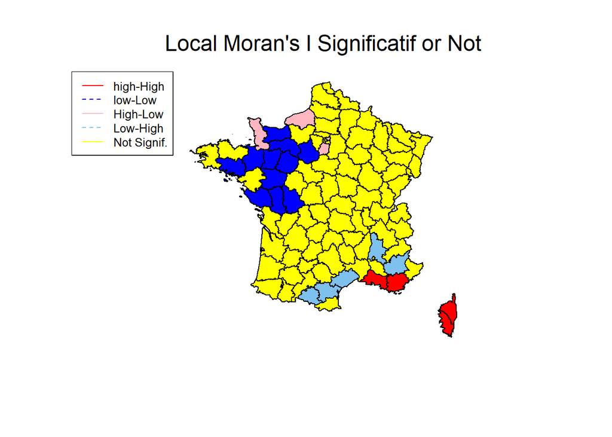

```r
labels <- c("high-High", "low-Low", "High-Low", "Low-High", "Not Signif.")

# need for the map
help("findInterval")
breaks <- seq(1, 5, 1)

carte$np_2 <- findInterval(carte$quad_sig_dist, breaks)

col.map <- c("red",  "blue","lightpink", "skyblue2", "yellow")
plot(carte, col = col.map[carte$np_2])
mtext("Local Moran's I Significatif or Not", cex = 1.5, side = 3, line = 1)
legend("topleft", legend = labels, col=c("red",  "blue","lightpink", "skyblue2","yellow"), lty=1:2, cex=0.8)
```

# Résumé

Matrice de contiguité : No Spatial Autocorrelation Matrice des plus plus proche voisin : Spatial Autocorrelation Matrice de l’inverse de la distance : Spatial Autocorrelation

# Estimation des modèles via la stratégie de test Top-Down

## Estimation des modèles

```r
library(spatialreg)
formule <- Cambriolage ~ Taux_chomage_2019 + Policier_Gendarme + Part_Maison + Personne_Seule
```

OLS

```r
Criminality_OLS <- lm(formula = formule, data = carte)
```

SLX : 𝑌=𝑋𝛽+𝑊𝑍𝛿+𝜀

```r
carte$Taux_chomage_2019_M <- carte$Taux_chomage_2019 -  mean(carte$Taux_chomage_2019)
carte$W_Taux_chomage_2019_M <- lag.listw(dist.w1, carte$Taux_chomage_2019_M)

carte$Policier_Gendarme_M <- carte$Policier_Gendarme - mean(carte$Policier_Gendarme)
carte$W_Policier_Gendarme_M <- lag.listw(dist.w1, carte$Policier_Gendarme_M)

carte$Part_Maison_M <- carte$Part_Maison - mean(carte$Part_Maison)
carte$W_Part_Maison_M <- lag.listw(dist.w1, carte$Part_Maison_M)

carte$Personne_Seule_M <- carte$Personne_Seule - mean(carte$Personne_Seule)
carte$w_Personne_Seule_M <- lag.listw(dist.w1, carte$Personne_Seule_M)

Criminality_SLX <- lm(Cambriolage_centered ~ Taux_chomage_2019_M + Policier_Gendarme_M + Part_Maison_M + Personne_Seule_M + W_Taux_chomage_2019_M + W_Policier_Gendarme_M + W_Part_Maison_M + w_Personne_Seule_M,data = carte)

summary(Criminality_SLX)
```

```
Call:
lm(formula = Cambriolage_centered ~ Taux_chomage_2019_M + Policier_Gendarme_M +
    Part_Maison_M + Personne_Seule_M + W_Taux_chomage_2019_M +
    W_Policier_Gendarme_M + W_Part_Maison_M + w_Personne_Seule_M,
    data = carte)

Residuals:
    Min      1Q  Median      3Q     Max
-4.8139 -1.0631 -0.2172  1.0979  4.5691

Coefficients:
                       Estimate Std. Error t value Pr(>|t|)
(Intercept)           -0.005620   0.189501  -0.030  0.97641
Taux_chomage_2019_M    0.458244   0.123935   3.697  0.00038 ***
Policier_Gendarme_M   -0.157891   0.200958  -0.786  0.43418
Part_Maison_M         -0.064567   0.013308  -4.852 5.33e-06 ***
Personne_Seule_M      -0.011761   0.007152  -1.644  0.10370
W_Taux_chomage_2019_M  0.550679   0.886617   0.621  0.53616
W_Policier_Gendarme_M  0.988681   1.651285   0.599  0.55091
W_Part_Maison_M       -0.003128   0.060669  -0.052  0.95900
w_Personne_Seule_M     0.034631   0.060989   0.568  0.57161
---
Signif. codes:  0 '***' 0.001 '**' 0.01 '*' 0.05 '.' 0.1 ' ' 1

Residual standard error: 1.846 on 87 degrees of freedom
Multiple R-squared:  0.4111,    Adjusted R-squared:  0.357
F-statistic: 7.593 on 8 and 87 DF,  p-value: 1.191e-07
```

SAR : 𝑌=𝜌𝑊𝑌+𝑋𝛽+𝜀

```r
Criminality_SAR <- lagsarlm(formula = formule, listw = dist.w1, data = carte)
```

SEM : 𝑌=𝑋𝛽+ε,𝜀=𝜆𝑊𝜀+𝑈

```r
Criminality_SEM = errorsarlm(formula = formule, listw=dist.w1,  data=carte)
```

SDM : 𝑌=𝜌𝑊𝑌+𝑋𝛽+𝑊𝑋𝛿+𝜀

```r
Criminality_SDM <- lagsarlm(formula = formule, listw = dist.w1, type = "mixed", data = carte)
```

## Strategy of test Top Down approach LeSage & Pace (2009)

SDM VS SAR : On test

H0 : 𝛿 = 0 , If H0 rejected = SDM

```r
sdm_vs_sar <- LR.Sarlm(Criminality_SDM,Criminality_SAR)
print(sdm_vs_sar)
```

```
    Likelihood ratio for spatial linear models

data:
Likelihood ratio = 2.6416, df = 4, p-value = 0.6195
sample estimates:
Log likelihood of Criminality_SDM Log likelihood of Criminality_SAR
                        -190.3348                         -191.6556
```

On a p-value = 0.6195 > 0.05 => On ne rejette pas HO donc 𝛿 = 0 sar_vs_ols

```r
sar_vs_ols <- LR.Sarlm(Criminality_SAR,Criminality_OLS)
print(sar_vs_ols)
```

```
    Likelihood ratio for spatial linear models

data:
Likelihood ratio = 0.70297, df = 1, p-value = 0.4018
sample estimates:
Log likelihood of Criminality_SAR Log likelihood of Criminality_OLS
                        -191.6556                         -192.0071
```

p-value = 0.4018, on ne rejette pas HO donc p = OLS => Modele OLS

SDM vs SLX

H0 : rho=0, teta not = 0 et teta + rho*beta != 0 unconstrained model : SDM constrainted model : SLX If H0 reject : SDM

```r
sdm_vs_slx <- LR.Sarlm(Criminality_SDM, Criminality_SLX)
print(sdm_vs_slx)
```

```
    Likelihood ratio for spatial linear models

data:
Likelihood ratio = 0.024426, df = 1, p-value = 0.8758
sample estimates:
Log likelihood of Criminality_SDM Log likelihood of Criminality_SLX
                        -190.3348                         -190.3470
```

p-value = O.8759 > 5%, on accepte HO

slx_vs_ols

```r
slx_vs_ols<-LR.Sarlm(Criminality_SLX,Criminality_OLS)
print(slx_vs_ols)
```

```
    Likelihood ratio for spatial linear models

data:
Likelihood ratio = 3.3201, df = 4, p-value = 0.5057
sample estimates:
Log likelihood of Criminality_SLX Log likelihood of Criminality_OLS
                        -190.3470                         -192.0071
```

p-value = 0.5058 > 5% ==> p = 0 ==> Modele OLS

sdm_vs_sem

```r
sdm_vs_sem <-LR.Sarlm(Criminality_SDM,Criminality_SEM)
print(sdm_vs_sem)
```

```
    Likelihood ratio for spatial linear models

data:
Likelihood ratio = 3.3142, df = 4, p-value = 0.5067
sample estimates:
Log likelihood of Criminality_SDM Log likelihood of Criminality_SEM
                        -190.3348                         -191.9919
```

p-value = 0.5067 > 0.05 , on accepte HO

```r
sem_vs_ols<-LR.Sarlm(Criminality_SEM,Criminality_OLS)
print(sem_vs_ols)
```

```
    Likelihood ratio for spatial linear models

data:
Likelihood ratio = 0.030321, df = 1, p-value = 0.8618
sample estimates:
Log likelihood of Criminality_SEM Log likelihood of Criminality_OLS
                        -191.9919                         -192.0071
```

p-value= 0.8618, on chosit donc le modèle OLS

## Test sur le modele

```r
summary(Criminality_OLS)
```

```
Call:
lm(formula = formule, data = carte)

Residuals:
    Min      1Q  Median      3Q     Max
-5.1055 -1.0781 -0.2373  1.1486  5.6935

Coefficients:
                   Estimate Std. Error t value Pr(>|t|)
(Intercept)       12.025975   2.719695   4.422  2.7e-05 ***
Taux_chomage_2019  0.470191   0.119143   3.946 0.000156 ***
Policier_Gendarme -0.184602   0.177755  -1.039 0.301780
Part_Maison       -0.071505   0.011779  -6.070  2.9e-08 ***
Personne_Seule    -0.013267   0.006621  -2.004 0.048071 *
---
Signif. codes:  0 '***' 0.001 '**' 0.01 '*' 0.05 '.' 0.1 ' ' 1

Residual standard error: 1.837 on 91 degrees of freedom
Multiple R-squared:  0.3904,    Adjusted R-squared:  0.3636
F-statistic: 14.57 on 4 and 91 DF,  p-value: 3.109e-09
```

```r
Moran_Res <- lm.morantest(Criminality_OLS, listw = dist.w1, alternative = "two.sided")
Moran_Res
```

```
    Global Moran I for regression residuals

data:
model: lm(formula = formule, data = carte)
weights: dist.w1

Moran I statistic standard deviate = 0.70976, p-value = 0.4779
alternative hypothesis: two.sided
sample estimates:
Observed Moran I      Expectation         Variance
    0.0054479339    -0.0117653576     0.0005881748
```

```r
lmtest::bgtest(Criminality_OLS)
```

```
    Breusch-Godfrey test for serial correlation of order up to 1

data:  Criminality_OLS
LM test = 1.751, df = 1, p-value = 0.1858
```

p-value = 0.1859 > 0.05 ; On ne rejette donc pas l’hypothèse nulle,